# Análisis Multivariado - Clase 5

2025-09-02

## Kernels

## Kernels

- Son funciones con un número real como único argumento
- Las funciones siempre alcanzan su máximo en 0
- A medida que el argumento se aleja del cero, las imágenes del Kernel disminuyen
- Su integral en todos los números reales da 1 como resultado.

## Kernel Uniforme

\[K_U(u)=\dfrac{1}{2}\cdot \mathbb{I}_{|u|\le 1} =\left\lbrace \begin{array}{lll} \frac{1}{2} & & \text{si }-1\le u\le 1\\ 0& & \text{caso contrario} \end{array}\right.\]

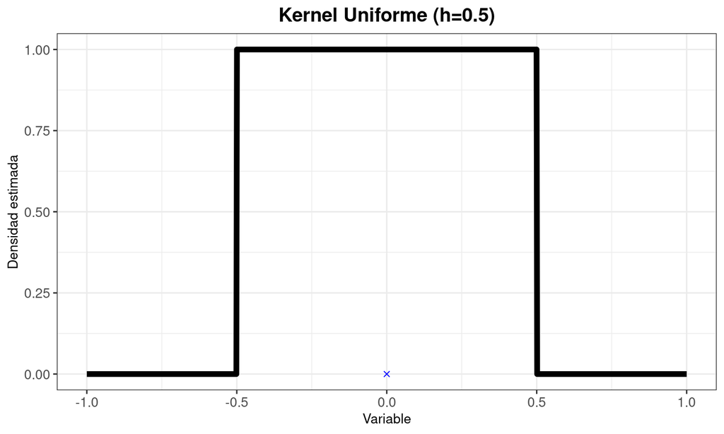

## Kernel Triangular

\[K_T(u)=(1-|u|)\cdot \mathbb{I}_{|u|\le 1} =\left\lbrace \begin{array}{lll} 1+u & & \text{si }-1\le u\le 0\\ 1-u & & \text{si }0\le u\le 1\\ 0& & \text{caso contrario} \end{array}\right.\]

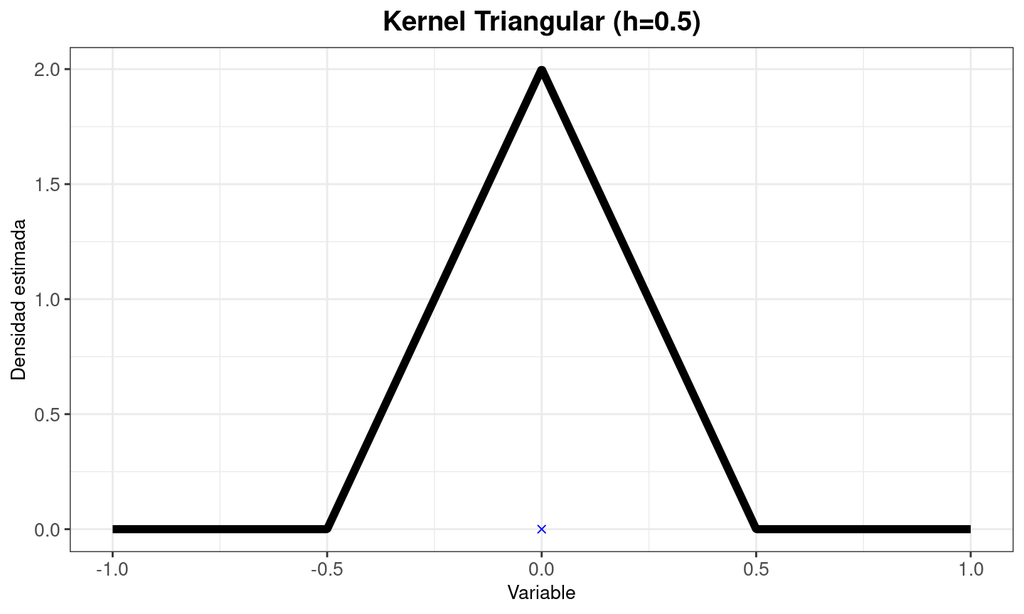

## Kernel Epanechnikov

\[K_E(u)=\dfrac{3}{4}\cdot (1-u^2)\cdot \mathbb{I}_{|u|\le 1} =\left\lbrace \begin{array}{lll} \dfrac{3}{4}\cdot (1-u^2) & & \text{si }-1\le u\le 1\\ 0& & \text{caso contrario} \end{array}\right.\]

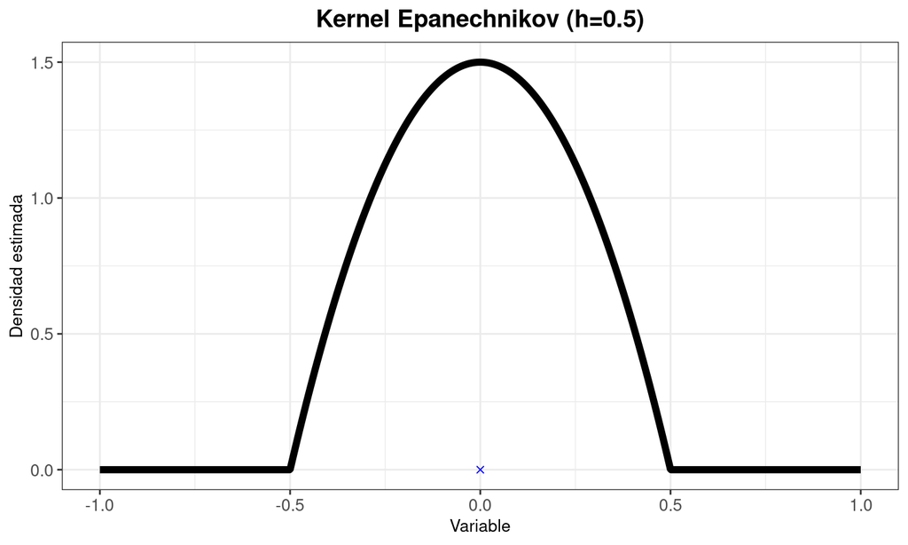

## Kernel Cuártico

\[K_Q(u)=\dfrac{15}{16}\cdot (1-u^2)^2\cdot \mathbb{I}_{|u|\le 1} =\left\lbrace \begin{array}{lll} \dfrac{15}{16}\cdot (1-u^2)^2 & & \text{si }-1\le u\le 1\\ 0& & \text{caso contrario} \end{array}\right.\]

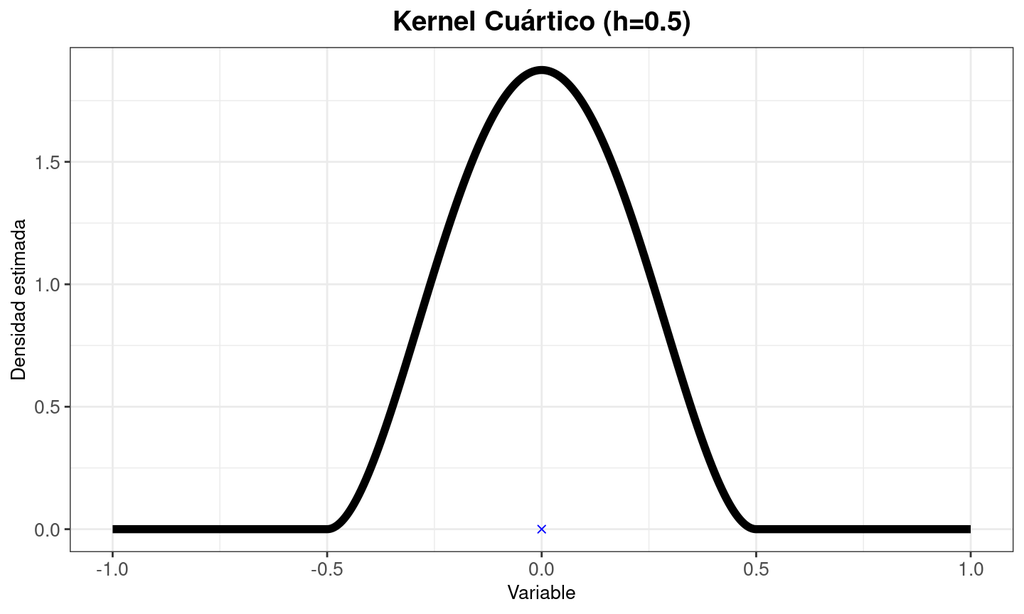

## Kernel Radial

\[K_R(u)=\dfrac{1}{\sqrt{2\pi}}\cdot e^{-\frac{u^2}{2}}\]

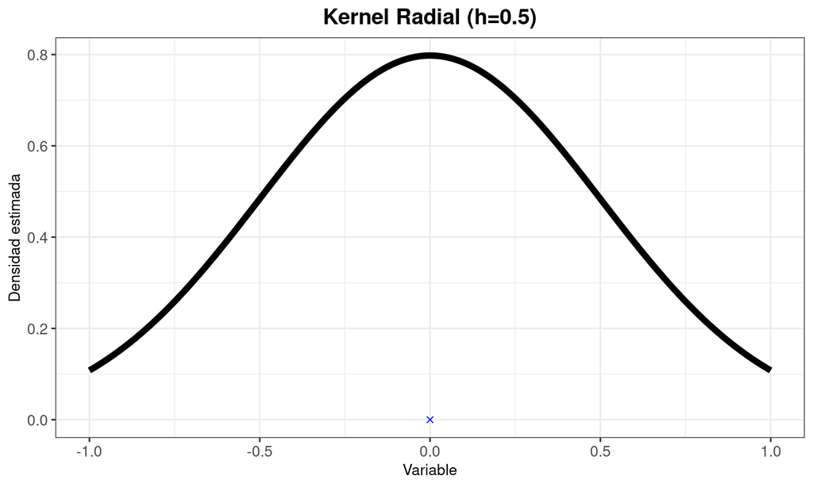

## Comparación

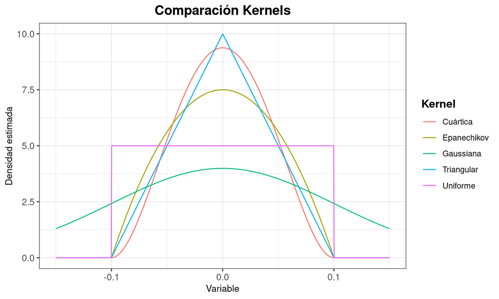

## Propiedades

Se puede usar cualquier Kernel para cuantificar similitud entre dos observaciones \(x\) e \(y\) del siguiente modo:

\[K\left(\dfrac{x-y}{h} \right) \] donde se denomina \(h\) el ancho de banda.

## Comparación de anchos de banda (Kernel Uniforme)

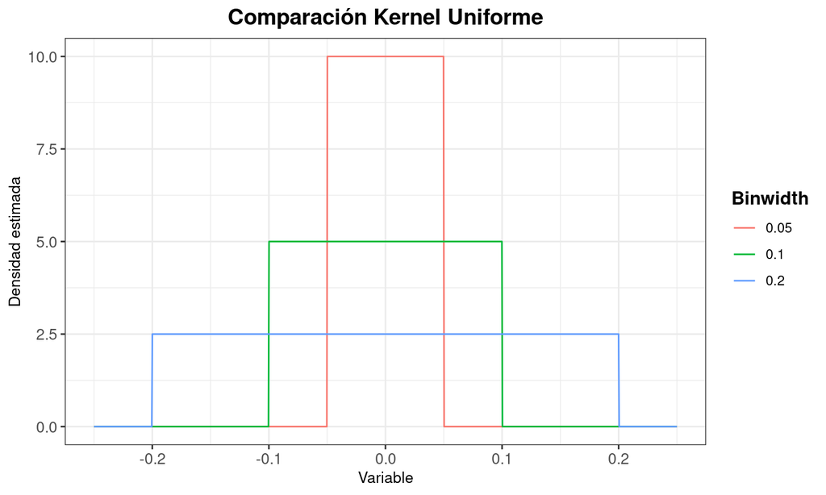

## Comparación de anchos de banda (Kernel Triangular)

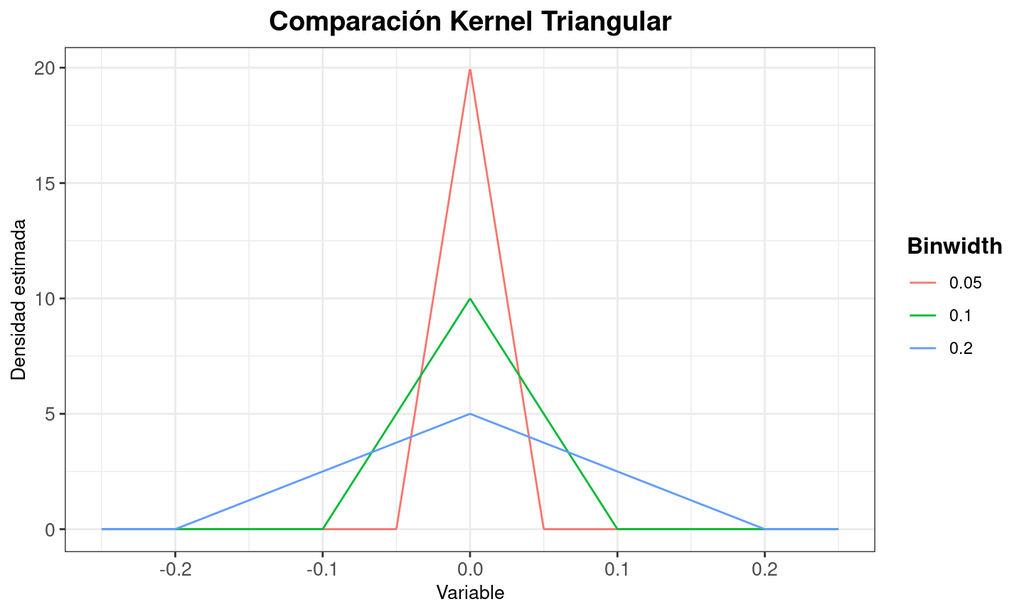

## Comparación de anchos de banda (Kernel Epanechnikov)

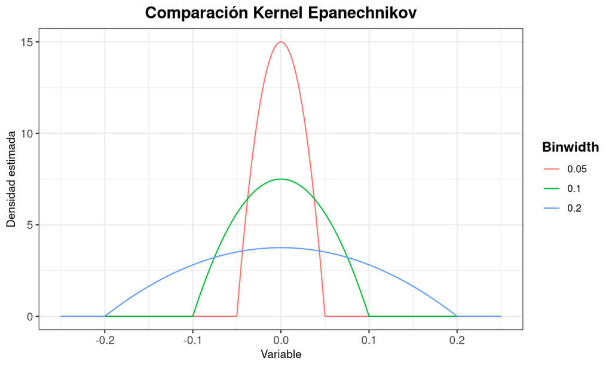

## Comparación de anchos de banda (Kernel Cuártico)

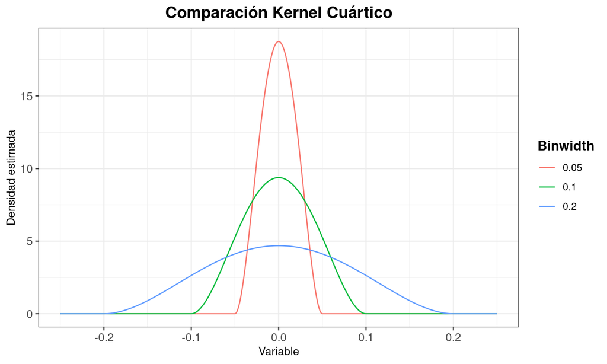

## Comparación de anchos de banda (Kernel Radial)

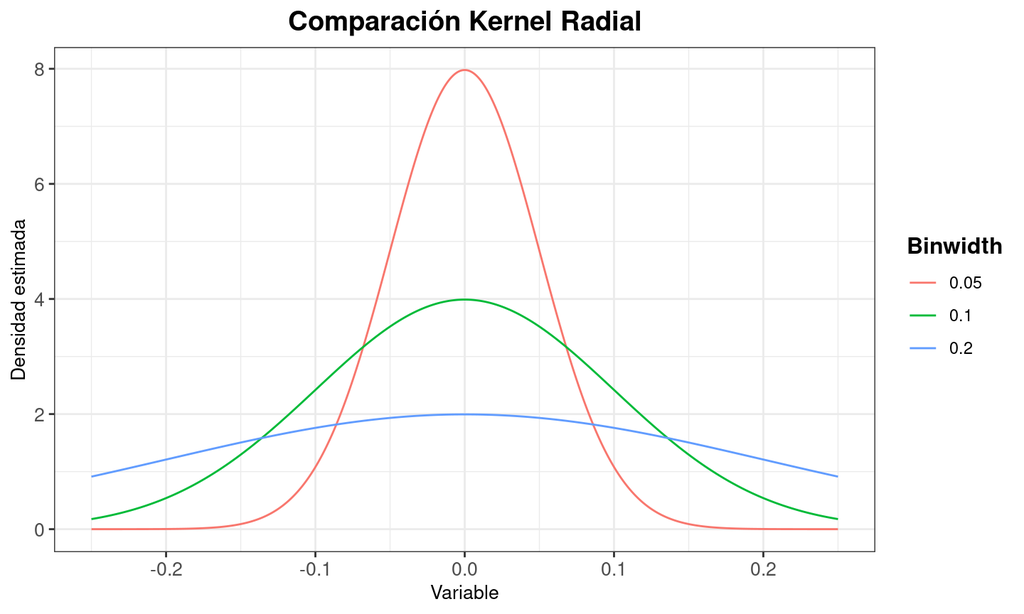

## Estimación de densidad

```
##  [1]  1.26 -0.33  1.33  1.27  0.41 -1.54 -0.93 -0.29 -0.01  2.40
```

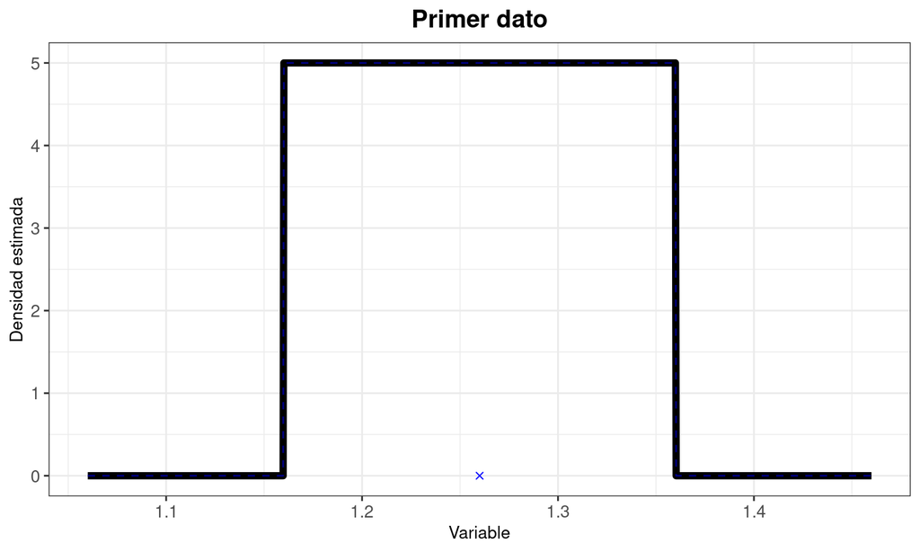

## Estimación de densidad

```
##  [1]  1.26 -0.33  1.33  1.27  0.41 -1.54 -0.93 -0.29 -0.01  2.40
```

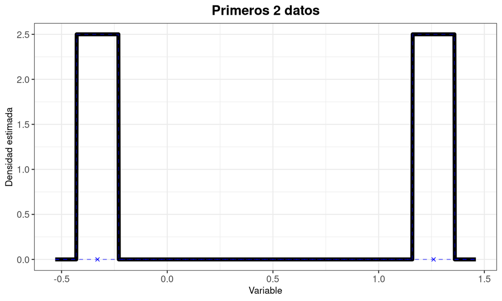

## Estimación de densidad

```
##  [1]  1.26 -0.33  1.33  1.27  0.41 -1.54 -0.93 -0.29 -0.01  2.40
```

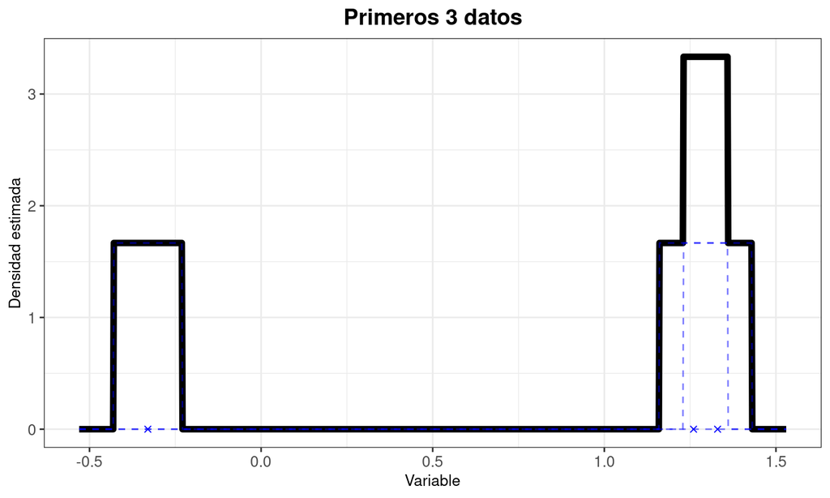

## Estimación de densidad (Kernel Uniforme)

```
##  [1]  1.26 -0.33  1.33  1.27  0.41 -1.54 -0.93 -0.29 -0.01  2.40
```

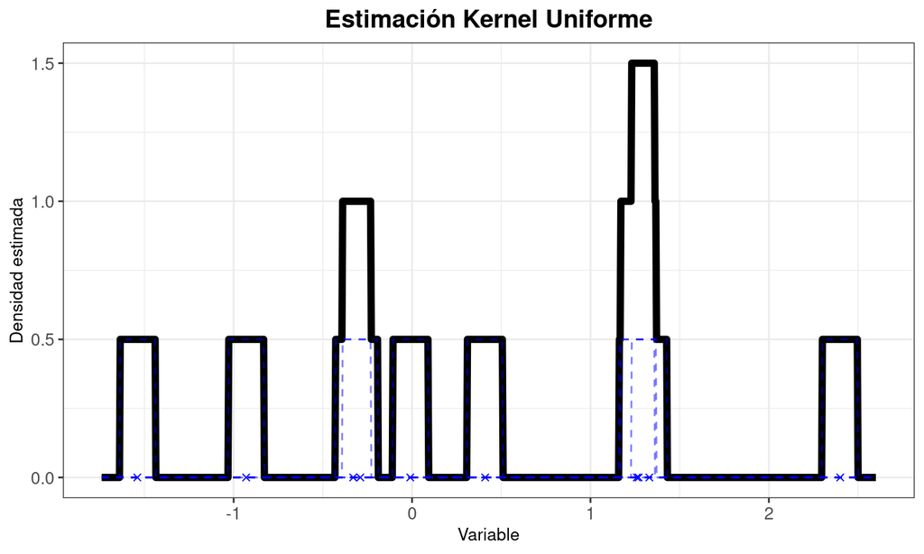

## Estimación de densidad (Kernel Triangular)

```
##  [1]  1.26 -0.33  1.33  1.27  0.41 -1.54 -0.93 -0.29 -0.01  2.40
```

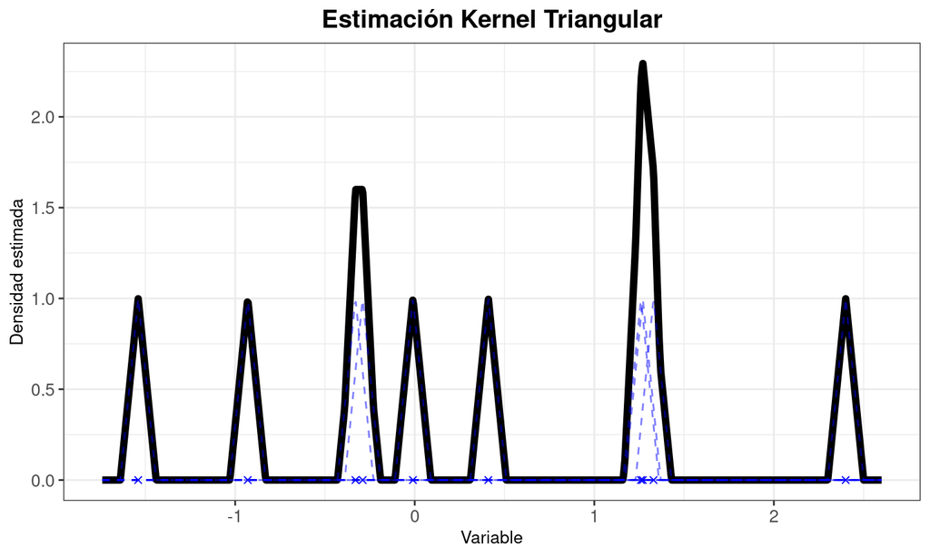

## Estimación de densidad (Kernel Epanechnikov)

```
##  [1]  1.26 -0.33  1.33  1.27  0.41 -1.54 -0.93 -0.29 -0.01  2.40
```

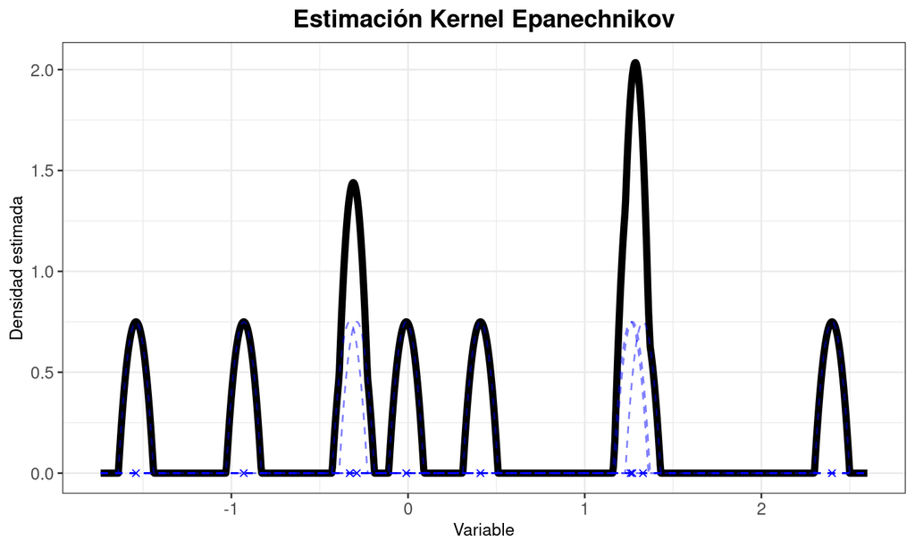

## Estimación de densidad (Kernel Cuártico)

```
##  [1]  1.26 -0.33  1.33  1.27  0.41 -1.54 -0.93 -0.29 -0.01  2.40
```

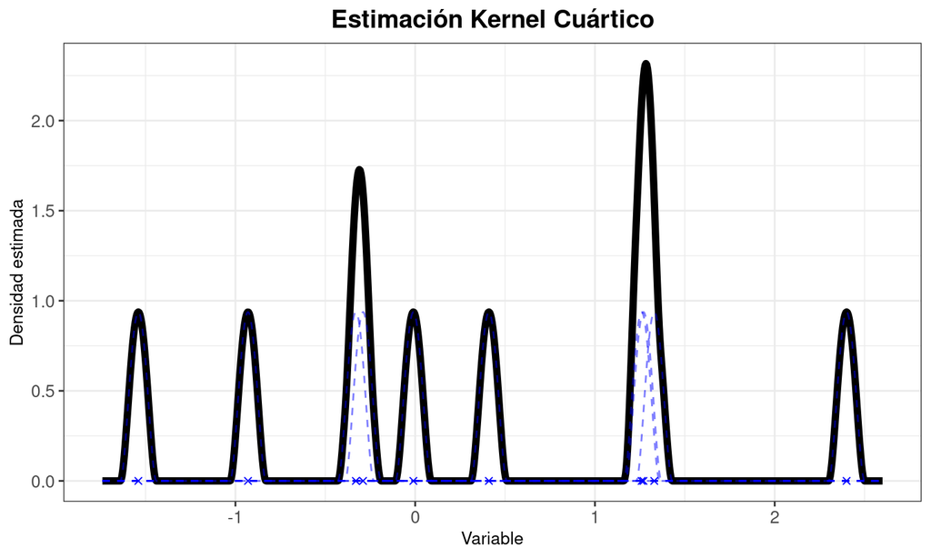

## Estimación de densidad (Kernel Radial)

```
##  [1]  1.26 -0.33  1.33  1.27  0.41 -1.54 -0.93 -0.29 -0.01  2.40
```

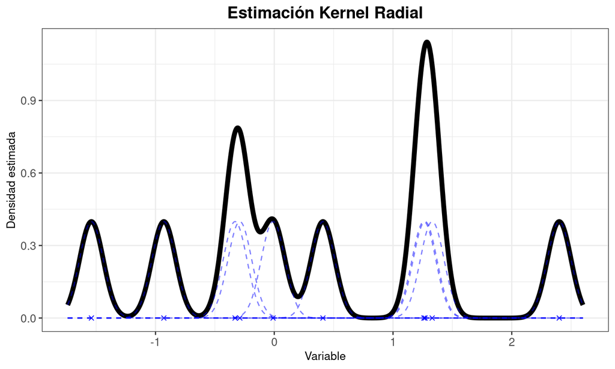

## Datos Simulados

```
##   Hidratación Alimentación Grupo Test Físico Test Cognitivo
## 1      100.50       104.12     A      151.45         300.13
## 2      112.14        89.32     A      193.11         264.78
## 3       98.73        98.20     A      212.24         316.16
## 4       97.83        98.72     A      255.00         334.29
## 5       93.98       100.89     A      137.10         300.20
## 6      101.93       103.70     A      204.11         315.93
```

## Estimación de Densidad Variable Hidratación (Kernel Uniforme)

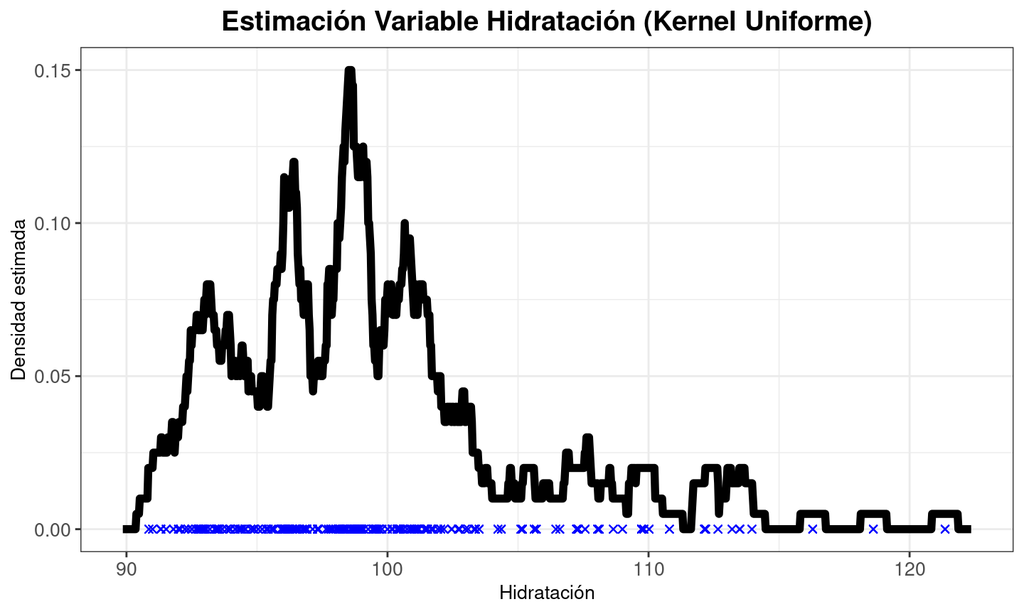

## Estimación de Densidad Variable Hidratación (Kernel Triangular)

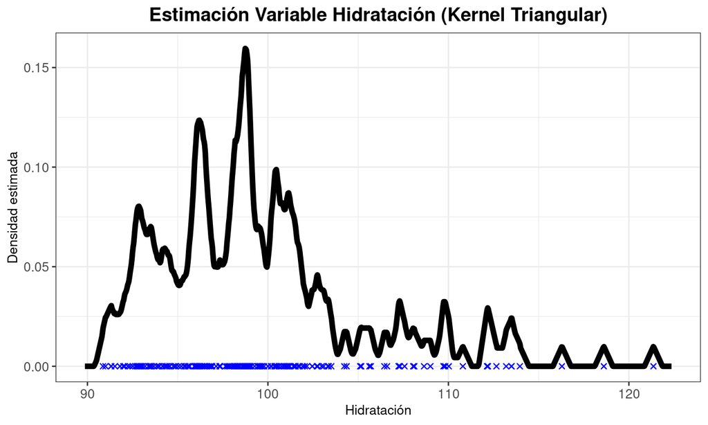

## Estimación de Densidad Variable Hidratación (Kernel Epanechnikov)

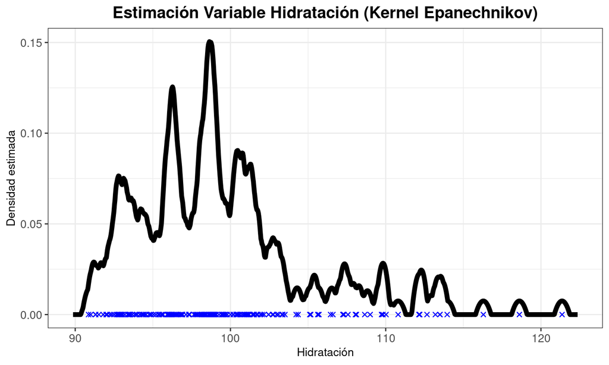

## Estimación de Densidad Variable Hidratación (Kernel Cuártico)

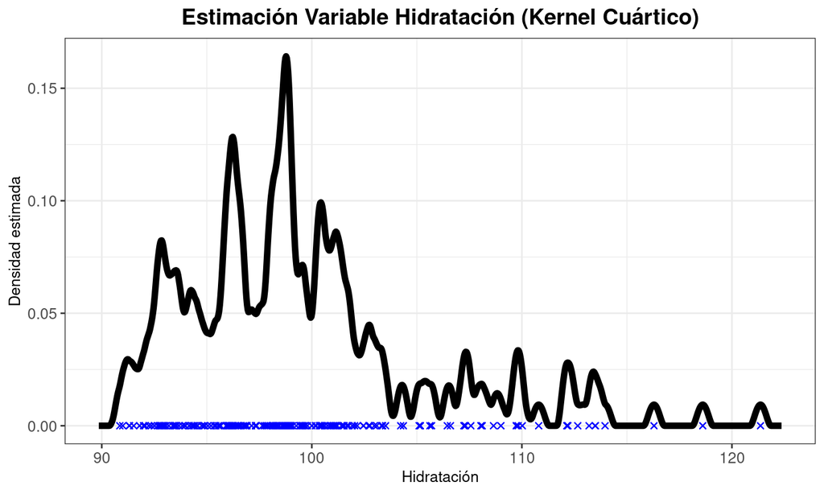

## Estimación de Densidad Variable Hidratación (Kernel Radial)

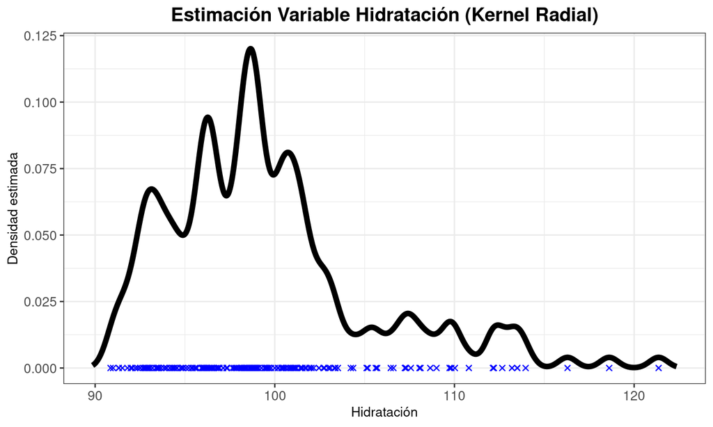

## Kernels para vectores

Cuando los datos son multivariados, se pueden ajustar los cálculos previos utilizando la distancia entre estos vectores. Es decir: \[\underset{\text{Univariado}}{\underbrace{K\left(\dfrac{x-y}{h} \right)}} \mapsto \underset{\text{Multivariado}}{\underbrace{K\left(\dfrac{||\mathbf{x}-\mathbf{y}||}{h} \right)}}\]

Aquí se agrega otra variante, que es que podemos utilizar distintas normas para medir la distancia entre vectores.

## Datos Simulados (Test Físico vs. Test Cognitivo - Grupo A)

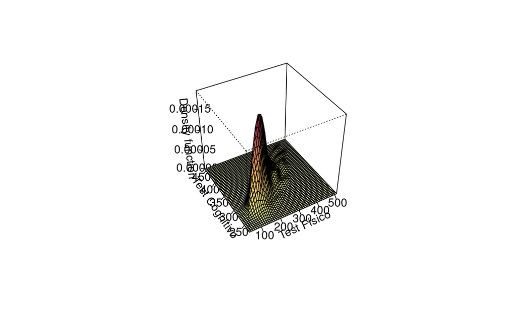

## Datos Simulados (Test Físico vs. Test Cognitivo - Grupo B)

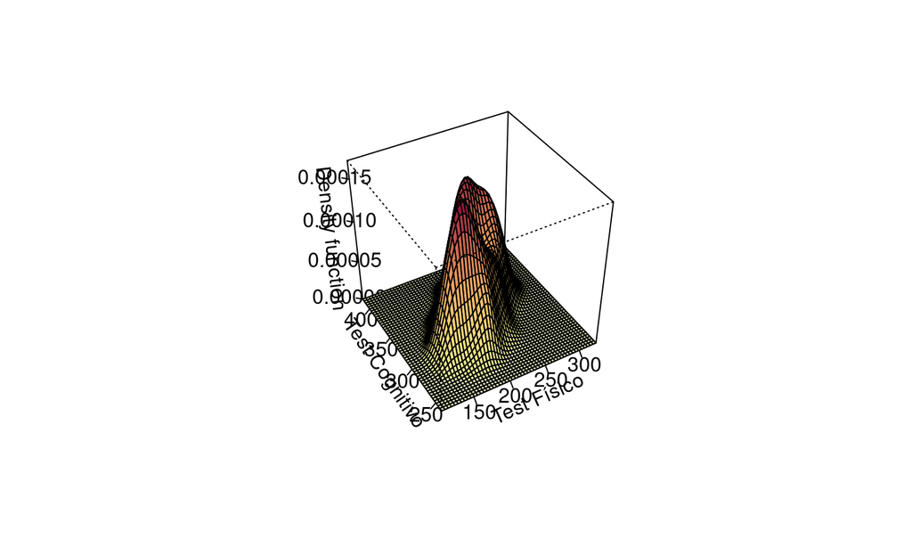

## Datos Simulados (Test Físico vs. Test Cognitivo - Grupo C)

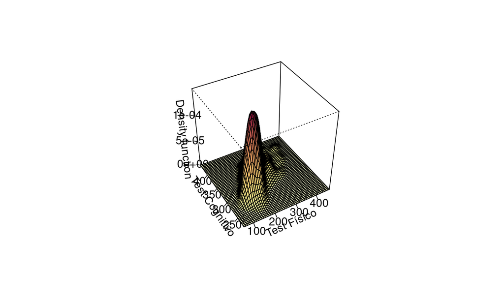

## Datos Simulados (Test Físico vs. Test Cognitivo - Grupo D)

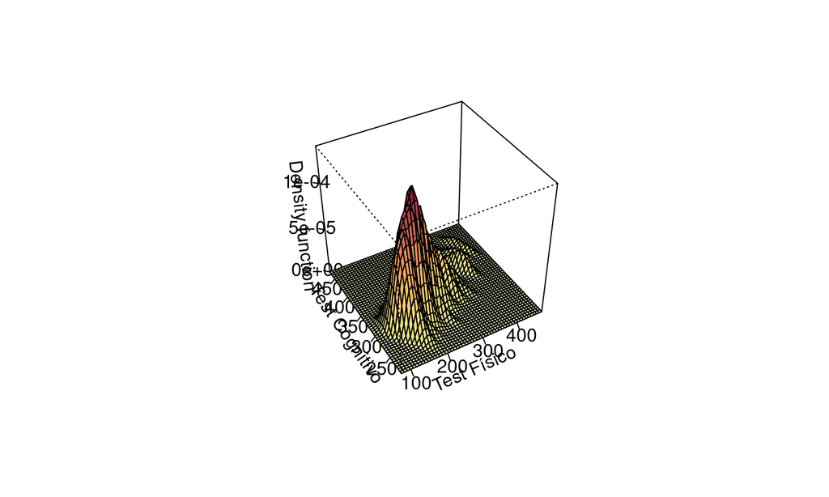

## Visualizaciones

## Base

```
##   Hidratación Alimentación Pantallas     Sueño      Test  Puntaje
## 1    94.69166     99.93649 113.06284  98.97909 Cognitivo 170.7152
## 2    97.82053     82.96936  91.43642 109.86590 Cognitivo 237.2545
## 3   101.56877    106.46284  94.15598 109.33415 Cognitivo 229.1970
## 4   101.93731     94.56491  91.99778  73.55282    Físico 222.0026
## 5    95.64230    106.28775  94.37241 102.26507 Cognitivo 217.0881
## 6    97.10112    107.53681  98.54202 107.97426 Cognitivo 218.3447
```

## Heat Map

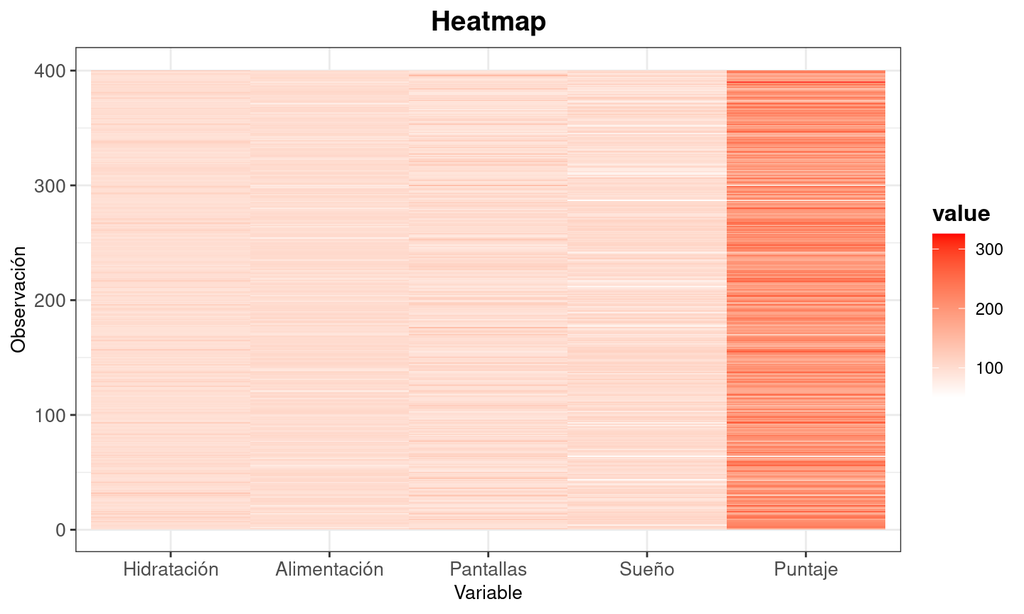

## Contornos de densidad (Alimentación vs Hidratación)

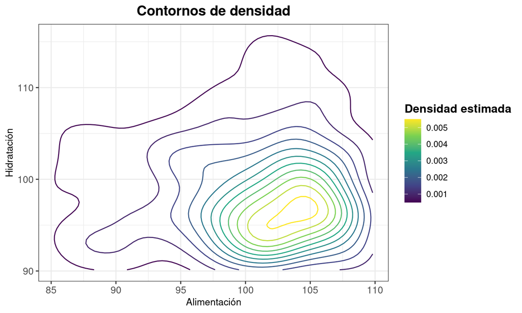